# Assignment3-Pratik-COVID_Vaccine_Sentiment.Rmd

# Sentiment Analysis:

Sentiment analysis is typically performed based on a lexicon of sentiment keywords.There are three such sentiment lexicons in **tidytext**:

- The **nrc** lexicon: word and their sentiment category
- The **bing** lexicon: word and their polarity (negative or positive)
- The **ann** lexicon: word and their numeric sentiment score

```r
testdata_text_sent<-get_nrc_sentiment((testdata_text))
```

Now, Let’s calculate the total score for each sentiment

```r
testdata_text_sent_score<-data.frame(colSums(testdata_text_sent[,]))

names(testdata_text_sent_score)<-"Score"
testdata_text_sent_score<-cbind("sentiment"=rownames(testdata_text_sent_score),testdata_text_sent_score)
rownames(testdata_text_sent_score)<-NULL
```

Now, Let’s plot the sentiments with scores

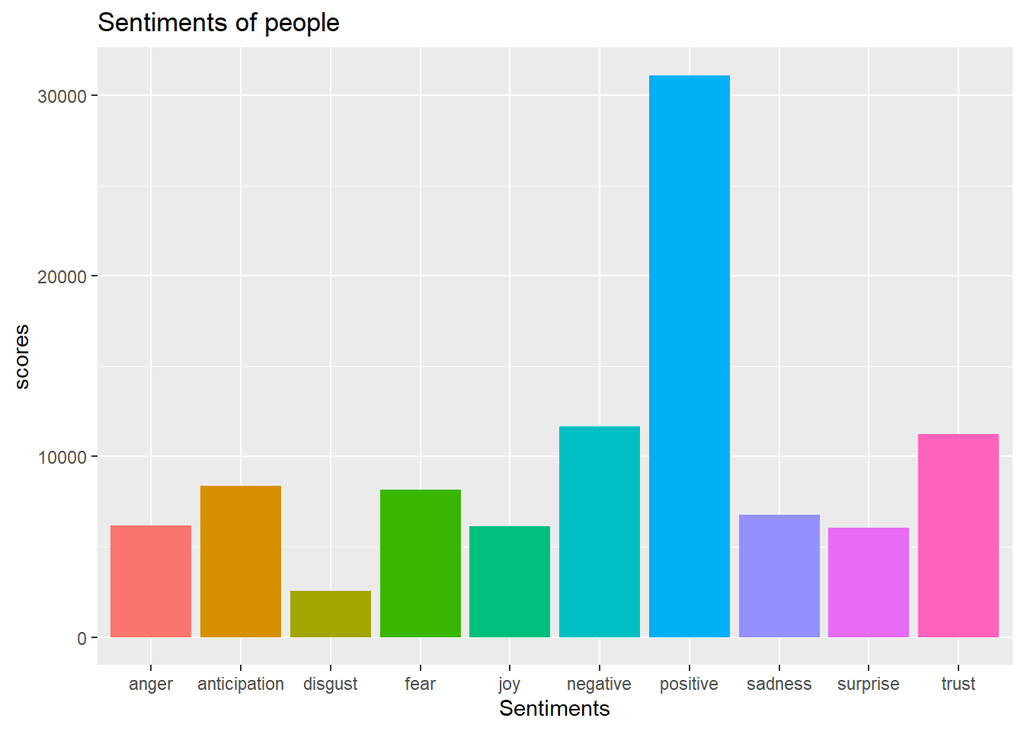

```r
ggplot(data=testdata_text_sent_score,aes(x=sentiment,y=Score))+geom_bar(aes(fill=sentiment),stat = "identity")+
  theme(legend.position="none")+
  xlab("Sentiments")+ylab("scores")+ggtitle("Sentiments of people ")
```

```r
testdata_text_sent<-get_nrc_sentiment((testdata_text))

testdata_text_sent_no_pos_neg<-select(testdata_text_sent,anger,anticipation,disgust,joy,sadness,surprise,trust)
```

Now, Let’s calculate the total score for each sentiment

```r
testdata_text_sent_no_pos_neg<-data.frame(colSums(testdata_text_sent_no_pos_neg[,]))

names(testdata_text_sent_no_pos_neg)<-"Score"
testdata_text_sent_no_pos_neg<-cbind("sentiment"=rownames(testdata_text_sent_no_pos_neg),testdata_text_sent_no_pos_neg)
rownames(testdata_text_sent_no_pos_neg)<-NULL
```

Now, Let’s plot the sentiments with scores

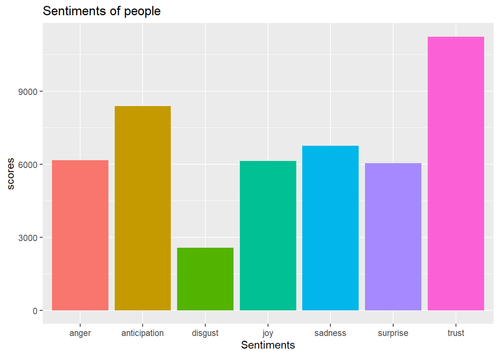

```r
ggplot(data=testdata_text_sent_no_pos_neg,aes(x=sentiment,y=Score))+geom_bar(aes(fill=sentiment),stat = "identity")+
  theme(legend.position="none")+
  xlab("Sentiments")+ylab("scores")+ggtitle("Sentiments of people ")
```

# Conclusion:

From the above graph, we can conclude that, people are showing trust and overall positive emotions for the covid vaccine . The anticipation of people is high.